# Inseason Bayesian Daily Projection for Canadian-origin Chinook Salmon

Aaron Lambert

2023-06-12

## June 12, 2023

Today’s forecast using the Bayesian Inseason projection for Canadian-origin Chinook salmon returning to the Yukon River is found below.

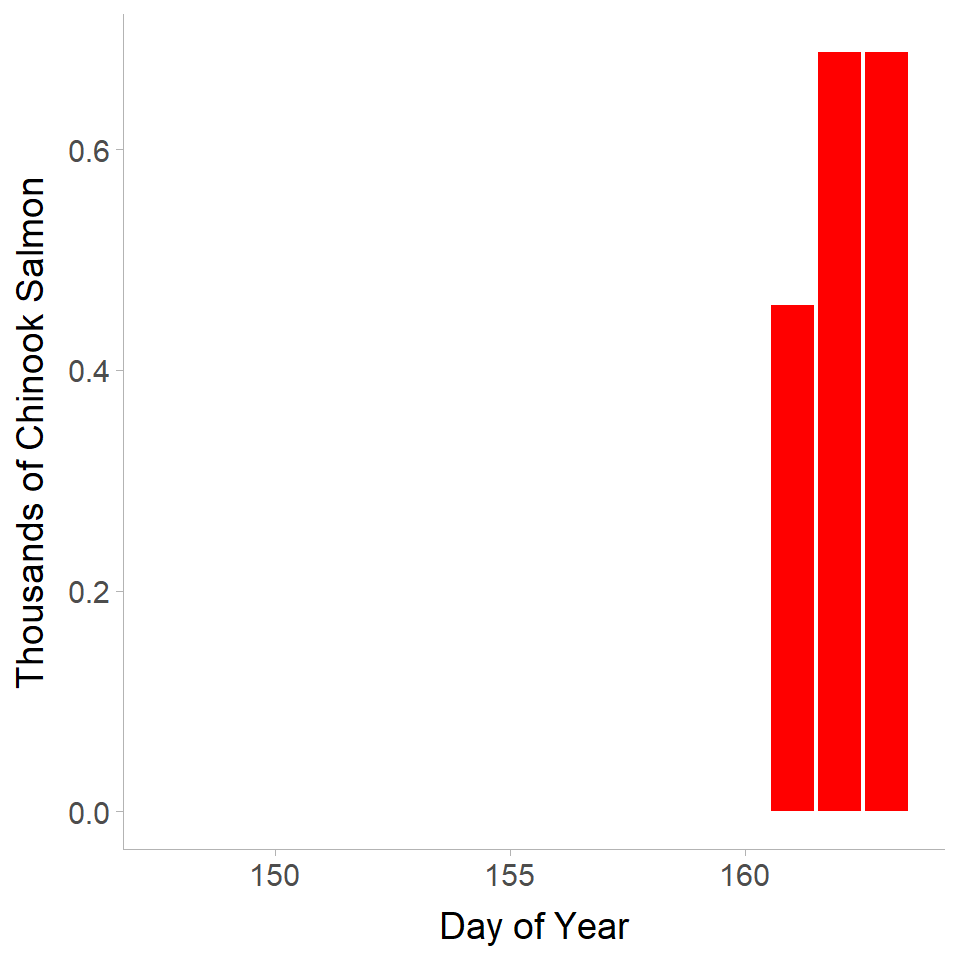

## Projected runsize quantiles

:

```
##  2.5%   10%   50%   90% 97.5%
## 22347 26693 37594 52224 62083
```

## Regression fit to the end-of-season cumulative PSS passage against historic observed Canadian-origin Chinook run size. Note that the current years prediction is based on summing up the observed passage up to the day of the forecast and adding the interpolated Chinook passage for the remainder of the season as predicted by fitting the normal distribution curve to observed passage.

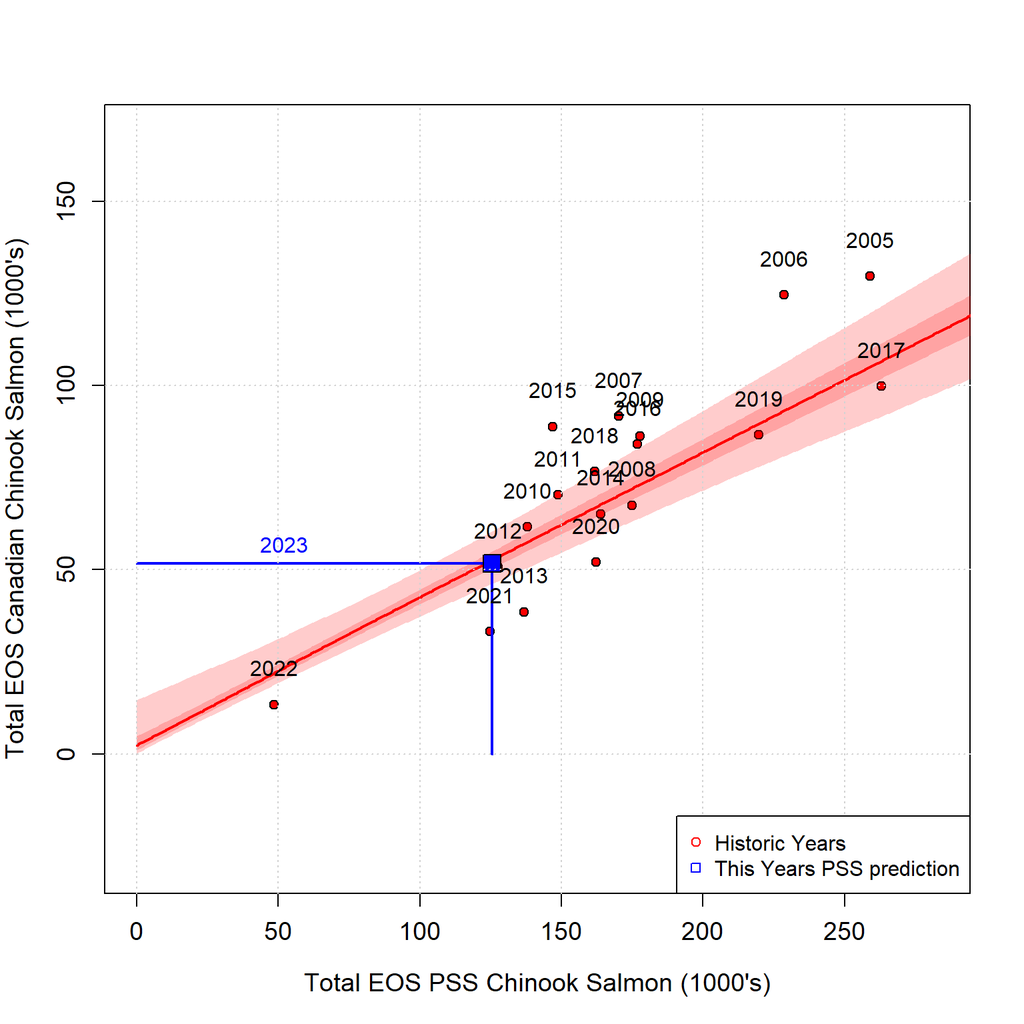

### Curve fit to observed daily PSS Chinook salmon passage. This curve is used to project the number of Chinook salmon that will pass PSS at the end of the season.

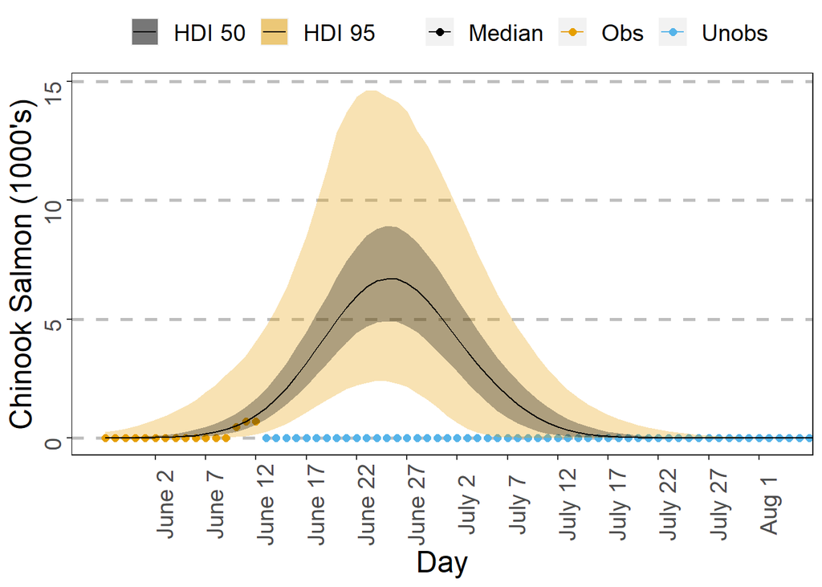

### Posterior density plots with the preseason forecast, PSS prediciton, Eagle Sonar prediction (when Chinook salmon are observed at the border), and the projected runsize.

[figure not shown]

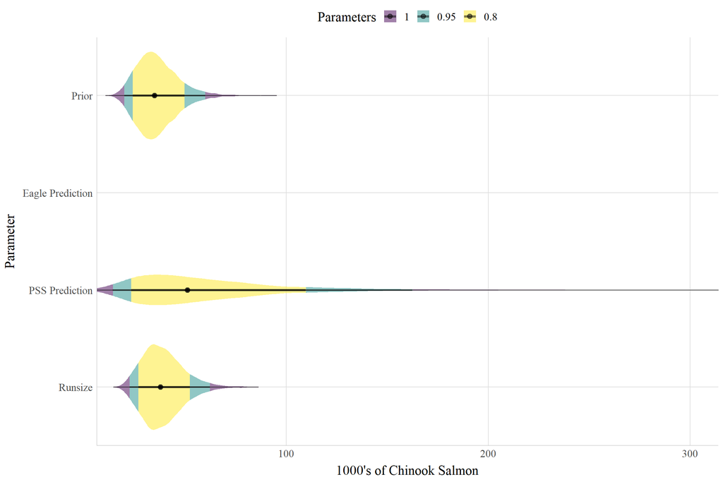